# S1.4f: un nucleo orientato solo in parte, quanto i nuclei veri, toglie i contatti in eccesso?

geo_spatialtrans, report di step (protocollo v2)

Published

October 29, 2026

# In breve

## In breve: un nucleo orientato solo in parte, quanto i nuclei veri, toglie i contatti in eccesso?

**A cosa serviva.** Nello step precedente un nucleo allungato, orientato esattamente lungo l’asse lungo del territorio della sua cellula, toglieva circa un contatto su dieci nei tessuti densi, ma allineava i nuclei più di quelli veri. Qui lo abbiamo orientato solo in parte, con una dispersione tarata perché i nuclei vicini fossero allineati quanto i veri, e abbiamo misurato di nuovo i contatti contro il tuo conteggio manuale. Serviva a sapere se forma e orientamento del nucleo spiegano i contatti in eccesso nel tumore del colon, nello stroma del tumore e nel linfonodo.

**Cosa abbiamo trovato**

1. **Con l’allineamento giusto il nucleo toglie circa metà dei contatti tolti dall’orientamento esatto: non basta, e il disco resta nei preset.**
   - Nuclei con almeno un vicino a contatto, dal disco al nucleo orientato in parte: intestino 0.57 → 0.51; tumore del colon 0.69 → 0.64 (vero al più 0.57); stroma 0.36 → 0.34 (al più 0.28); linfonodo 0.83 → 0.78 (al più 0.75). Nello stroma l’effetto è un quarto di quello dell’orientamento esatto.
   - Il tumore del colon e il linfonodo restano fuori dal vero, lo stroma al limite. Il nucleo orientato in parte riproduce 3 misure di contatto su 10, come il disco; la regola fissata prima del calcolo ne chiedeva almeno 2 in più.
2. **L’allineamento dei nuclei vicini è giusto in tutti e cinque i tessuti in cui lo abbiamo misurato**, anche se la dispersione è tarata su aree diverse da quella giudicata.
3. **Ma a 5-8 µm dal vicino i nuclei simulati restano troppo allineati, con tutte e tre le regole di dispersione provate.**
   - Nell’intestino, con il vicino a 6-8 µm, i nuclei veri sono orientati come a caso (metà di traverso al vicino); i simulati 62 su 100.
   - Non dipende dai territori: a quella distanza l’asse del territorio è di traverso al vicino circa 8 volte su 10 sia nei tessuti veri sia nei simulati. È il nucleo vero che smette di seguire la forma del territorio quando il vicino non lo stringe.
   - Una regola che lo seguisse meno a distanza media toglierebbe ancora meno contatti: il punto 1 non cambia.
4. **Sui tuoi stessi punti il nucleo orientato in parte toglie da 3 a 7 coppie a contatto su 100 sotto i 6 µm, circa metà dell’orientamento esatto.** Togliere i nuclei contati due volte al bordo delle finestre non cambia il risultato.

**Cosa devi decidere**

1. **Chiudiamo il lavoro sul disegno del nucleo, teniamo il disco nei preset e dichiariamo l’eccesso di contatti che resta come limite del simulatore? Consiglio di sì.**
   - Abbiamo provato il disco, l’ellisse a caso, l’ellisse orientata esattamente e tre modi di orientarla in parte: l’orientamento realistico spiega circa metà dell’effetto dell’orientamento esatto, e l’orientamento esatto non è realistico.
   - Nel tumore del colon l’eccesso più grande sta dove il riferimento manuale è meno sicuro: sulle stesse coppie vicine tu vedi contatti in 17 su 100, Federica in 44.
   - Alternativa: cercare un’altra causa, per esempio nuclei che nell’immagine si sovrappongono perché stanno a profondità diverse nello spessore della sezione. È un modello nuovo, da fare in uno step a sé, e servono riferimenti da cercare.
   - Alternativa: una regola dell’orientamento che cali più in fretta con la distanza, solo per avere l’allineamento giusto anche a 5-8 µm. Non toglierebbe contatti; servirebbe a chi usa il simulatore per testare metodi sulla forma dei nuclei.

**Comunque**

- I preset non cambiano. Il nucleo orientato in parte resta nel pacchetto come opzione, con le sue tre regole di dispersione.
- Una regola dell’orientamento che cali più in fretta con la distanza resta annotata fra le cose da fare, e si farà solo se lo sceglierai.

Appena decidi questo punto, lo step è chiuso.

**Sui tempi di calcolo.** La stima di 2,5-3 ore con 20 processori era mia, ricavata dai tempi dello step precedente. Il calcolo è durato circa un’ora con 20 processori sul server del laboratorio: la taratura (5 400 nuclei ridisegnati per simulazione) 24,5 minuti, le 300 simulazioni 12,2 minuti, le 24 finestre sui tuoi punti 8,3 minuti. Il resto sono state misure brevi. Test, mutanti e regressioni hanno richiesto circa mezz’ora per ogni passata, su pochi processori; le passate sono state tre, per via delle correzioni.

# Decisioni e verifiche di Luca

- «vai» (ok sulle previsioni, le regole O e N2, le controprove e la sensibilità S-1, dalla chat, 2026-10-28)
- Decisione sul riassunto (chiudere il lavoro sul disegno del nucleo, disco nei preset, eccesso di contatti come limite dichiarato): «accetto suggerimento. chiudi» (chat, 2026-10-29)
- Decisione registrata in S1.4f: si chiude il lavoro sul disegno del nucleo; il disco resta nei preset e l’eccesso di contatti che resta è un limite dichiarato del simulatore (DEC-029). Luca ha letto il riassunto senza sollevare dubbi nuovi: step chiuso.

# Dubbi rinviati

| cosa | perché | cosa serve per chiuderlo | step destinatario | voce di BACKLOG |
| --- | --- | --- | --- | --- |
| allineamento troppo alto a 5-8 µm dal vicino con tutte e tre le leggi della dispersione (P-5 smentita, 4/8 per la compressione) | il nucleo vero segue il territorio solo quando il vicino lo stringe (PH-1); le leggi a un parametro calano troppo piano con la distanza | legge a due parametri (per esempio concentrazione nulla sotto una soglia di compressione) o orientamento rispetto al vicino invece che al territorio, tarata come qui e giudicata su P-3 e P-5; non togl… | da assegnare (solo se Luca lo sceglie) | BL-175 |
| eccesso di contatti che resta nel tumore del colon e nel linfonodo (e al limite nello stroma) con ogni disegno del nucleo provato | il disegno del nucleo ne spiega una parte; il resto ha un’altra causa o sta nel riferimento manuale | **deciso da Luca** (2026-10-29, «accetto suggerimento. chiudi»): limite dichiarato, il disco resta nei preset (S1.4f: si chiude il lavoro sul disegno del nucleo; il disco resta nei preset e l’eccesso … | nessuno (chiuso) | BL-166, BL-142 |

# Cancelli, previsioni e regole

Pre-registrazione al commit `ebb2b34`; ok di Luca il 2026-10-28 («vai», commit `5577770`). Codice e test al commit `ea26c00`; risultati prima della revisione `176e93c`.

Bracci: **K2** il disco di oggi, ritagliato nel territorio e riportato all’area giusta; **ET** ellisse con l’allungamento vero del tessuto, esattamente lungo l’asse maggiore del territorio; **EP** la stessa ellisse orientata in parte: angolo del territorio più una deviazione dalla Cauchy avvolta, con concentrazione legata alla compressione della cellula (legge scelta dalla regola O) e tarata sull’allineamento vero sotto i 5 µm con pieghe lascia-fuori-un-ROI. Stessi centri, territori, semi e aree bersaglio.

Previsioni: stima ± 2 errori standard ed esito per braccio (P-1, P-2: seme; P-3, P-4, P-5: ROI)

| id | tessuto | classe | intervallo | K2 | EP | ET |
| --- | --- | --- | --- | --- | --- | --- |
| P-1 | intestino di topo |  | 0.366-0.650 | 0.569 ± 0.024 confermata | 0.514 ± 0.025 confermata | 0.472 ± 0.023 confermata |
| P-1 | tumore del colon |  | 0.217-0.567 | 0.686 ± 0.044 smentita | 0.639 ± 0.040 smentita | 0.594 ± 0.030 indeterminata |
| P-1 | stroma del tumore |  | 0.083-0.283 | 0.360 ± 0.051 smentita | 0.340 ± 0.062 indeterminata | 0.279 ± 0.050 indeterminata |
| P-1 | linfonodo |  | 0.350-0.750 | 0.833 ± 0.019 smentita | 0.781 ± 0.024 smentita | 0.735 ± 0.019 indeterminata |
| P-1 | cervello di topo |  | 0.000-0.217 | 0.144 ± 0.016 confermata | 0.129 ± 0.021 confermata | 0.113 ± 0.017 confermata |
| P-1 | cuore |  | 0.000-0.070 | 0.070 ± 0.025 indeterminata | 0.065 ± 0.017 indeterminata | 0.057 ± 0.020 indeterminata |
| P-2 | intestino di topo |  | 0.235-0.481 | 0.521 ± 0.023 smentita | 0.463 ± 0.019 indeterminata | 0.418 ± 0.020 confermata |
| P-2 | tumore del colon |  | 0.083-0.515 | 0.865 ± 0.021 smentita | 0.792 ± 0.022 smentita | 0.743 ± 0.033 smentita |
| P-2 | stroma del tumore |  | 0.188-0.900 | 0.853 ± 0.041 confermata | 0.786 ± 0.038 confermata | 0.690 ± 0.060 confermata |
| P-2 | linfonodo |  | 0.139-0.451 | 0.549 ± 0.022 smentita | 0.493 ± 0.019 smentita | 0.450 ± 0.019 indeterminata |
| P-3 | intestino di topo |  | 0.757-0.776 | 0.995 ± 0.001 smentita | 0.767 ± 0.002 confermata | 0.860 ± 0.002 smentita |
| P-3 | tumore del colon |  | 0.834-0.893 | 0.995 ± 0.002 smentita | 0.866 ± 0.003 confermata | 0.921 ± 0.005 smentita |
| P-3 | stroma del tumore |  | 0.819-0.879 | 0.999 ± 0.001 smentita | 0.845 ± 0.005 confermata | 0.941 ± 0.004 smentita |
| P-3 | linfonodo |  | 0.752-0.786 | 0.999 ± 0.001 smentita | 0.773 ± 0.003 confermata | 0.890 ± 0.001 smentita |
| P-3 | cuore |  | 0.741-0.857 | 1.000 ± 0.000 smentita | 0.796 ± 0.036 confermata | 0.915 ± 0.020 smentita |
| P-4 | intestino di topo |  | 0.787-0.817 | 0.001 ± 0.000 smentita | 0.800 ± 0.000 confermata | 0.800 ± 0.000 confermata |
| P-4 | tumore del colon |  | 0.746-0.805 | 0.277 ± 0.016 smentita | 0.780 ± 0.000 confermata | 0.780 ± 0.000 confermata |
| P-4 | stroma del tumore |  | 0.761-0.871 | 0.000 ± 0.000 smentita | 0.810 ± 0.000 confermata | 0.810 ± 0.000 confermata |
| P-4 | linfonodo |  | 0.591-0.608 | 0.001 ± 0.000 smentita | 0.600 ± 0.000 confermata | 0.600 ± 0.000 confermata |
| P-4 | cervello di topo |  | 0.541-0.628 | 0.000 ± 0.000 smentita | 0.560 ± 0.000 confermata | 0.560 ± 0.000 confermata |
| P-4 | cuore |  | 0.771-0.866 | 0.000 ± 0.000 smentita | 0.810 ± 0.000 confermata | 0.810 ± 0.000 confermata |
| P-5 | intestino di topo | nn5-6 | 0.550-0.581 | 0.986 ± 0.011 smentita | 0.651 ± 0.004 smentita | 0.796 ± 0.002 smentita |
| P-5 | intestino di topo | nn6-8 | 0.479-0.501 | 0.983 ± 0.015 smentita | 0.619 ± 0.003 smentita | 0.785 ± 0.002 smentita |
| P-5 | tumore del colon | nn5-6 | 0.748-0.793 | 0.984 ± 0.001 smentita | 0.797 ± 0.004 indeterminata | 0.869 ± 0.005 smentita |
| P-5 | tumore del colon | nn6-8 | 0.645-0.674 | 0.953 ± 0.003 smentita | 0.726 ± 0.006 smentita | 0.822 ± 0.008 smentita |
| P-5 | stroma del tumore | nn5-6 | 0.709-0.779 | 0.995 ± 0.001 smentita | 0.756 ± 0.007 confermata | 0.880 ± 0.004 smentita |
| P-5 | stroma del tumore | nn6-8 | 0.569-0.667 | 0.983 ± 0.004 smentita | 0.659 ± 0.007 confermata | 0.838 ± 0.004 smentita |
| P-5 | linfonodo | nn5-6 | 0.654-0.673 | 0.992 ± 0.007 smentita | 0.665 ± 0.004 confermata | 0.831 ± 0.002 smentita |
| P-5 | linfonodo | nn6-8 | 0.540-0.580 | 0.960 ± 0.080 smentita | 0.629 ± 0.004 smentita | 0.799 ± 0.004 smentita |

P-5 per le tre leggi (V0 costante, V1 allungamento del territorio, V2 compressione = EP)

| legge | tessuto | classe | stima | intervallo | esito |
| --- | --- | --- | --- | --- | --- |
| V0 | intestino di topo | nn5-6 | 0.680 ± 0.004 | 0.550-0.581 | smentita |
| V0 | intestino di topo | nn6-8 | 0.669 ± 0.004 | 0.479-0.501 | smentita |
| V0 | tumore del colon | nn5-6 | 0.804 ± 0.005 | 0.748-0.793 | smentita |
| V0 | tumore del colon | nn6-8 | 0.744 ± 0.004 | 0.645-0.674 | smentita |
| V0 | stroma del tumore | nn5-6 | 0.761 ± 0.008 | 0.709-0.779 | confermata |
| V0 | stroma del tumore | nn6-8 | 0.679 ± 0.009 | 0.569-0.667 | smentita |
| V0 | linfonodo | nn5-6 | 0.675 ± 0.003 | 0.654-0.673 | indeterminata |
| V0 | linfonodo | nn6-8 | 0.650 ± 0.006 | 0.540-0.580 | smentita |
| V1 | intestino di topo | nn5-6 | 0.666 ± 0.002 | 0.550-0.581 | smentita |
| V1 | intestino di topo | nn6-8 | 0.641 ± 0.004 | 0.479-0.501 | smentita |
| V1 | tumore del colon | nn5-6 | 0.795 ± 0.005 | 0.748-0.793 | indeterminata |
| V1 | tumore del colon | nn6-8 | 0.726 ± 0.006 | 0.645-0.674 | smentita |
| V1 | stroma del tumore | nn5-6 | 0.752 ± 0.012 | 0.709-0.779 | confermata |
| V1 | stroma del tumore | nn6-8 | 0.662 ± 0.010 | 0.569-0.667 | indeterminata |
| V1 | linfonodo | nn5-6 | 0.654 ± 0.003 | 0.654-0.673 | indeterminata |
| V1 | linfonodo | nn6-8 | 0.611 ± 0.003 | 0.540-0.580 | smentita |
| V2 | intestino di topo | nn5-6 | 0.651 ± 0.004 | 0.550-0.581 | smentita |
| V2 | intestino di topo | nn6-8 | 0.619 ± 0.003 | 0.479-0.501 | smentita |
| V2 | tumore del colon | nn5-6 | 0.797 ± 0.004 | 0.748-0.793 | indeterminata |
| V2 | tumore del colon | nn6-8 | 0.726 ± 0.006 | 0.645-0.674 | smentita |
| V2 | stroma del tumore | nn5-6 | 0.756 ± 0.007 | 0.709-0.779 | confermata |
| V2 | stroma del tumore | nn6-8 | 0.659 ± 0.007 | 0.569-0.667 | confermata |
| V2 | linfonodo | nn5-6 | 0.665 ± 0.004 | 0.654-0.673 | confermata |
| V2 | linfonodo | nn6-8 | 0.629 ± 0.004 | 0.540-0.580 | smentita |

Regola O: caselle di P-5 dentro R-4 con i semi 1-5; pari punteggio deciso dalla somma degli scarti

| law | score | sum_absdev | winner |
| --- | --- | --- | --- |
| V2 | 3 | 0.412 | V2 |
| V1 | 3 | 0.445 | V2 |
| V0 | 1 | 0.560 | V2 |

Regola N2: conferme in P-1 e P-2; condizioni (a) almeno K2 + 2, (b) nessun tessuto confermato da K2 in P-1 diventa smentito, (c) P-3 smentita al più in 2 tessuti

| arm | score_P1_P2 | P3_confirmed | P3_refuted | cond_a | cond_b | cond_c | winner | why |
| --- | --- | --- | --- | --- | --- | --- | --- | --- |
| K2 | 3 | 0 | 5 | True | True | True | K2 | nessun braccio ammesso dalle condizioni (a), (b), (c) |
| ET | 4 | 0 | 5 | False | True | False | K2 | nessun braccio ammesso dalle condizioni (a), (b), (c) |
| EP | 3 | 5 | 0 | False | True | True | K2 | nessun braccio ammesso dalle condizioni (a), (b), (c) |

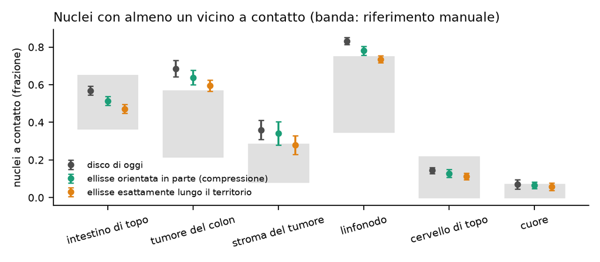

Nuclei con almeno un vicino a contatto nelle finestre contate a mano, per tessuto e braccio (stima ± 2 errori standard, 10 semi). Banda grigia: riferimento manuale (B-127…B-132).

Cosa guardare: il nucleo orientato in parte (verde) sta circa a metà fra il disco (grigio) e l’ellisse orientata esattamente (arancione); nel tumore del colon e nel linfonodo resta sopra la banda.

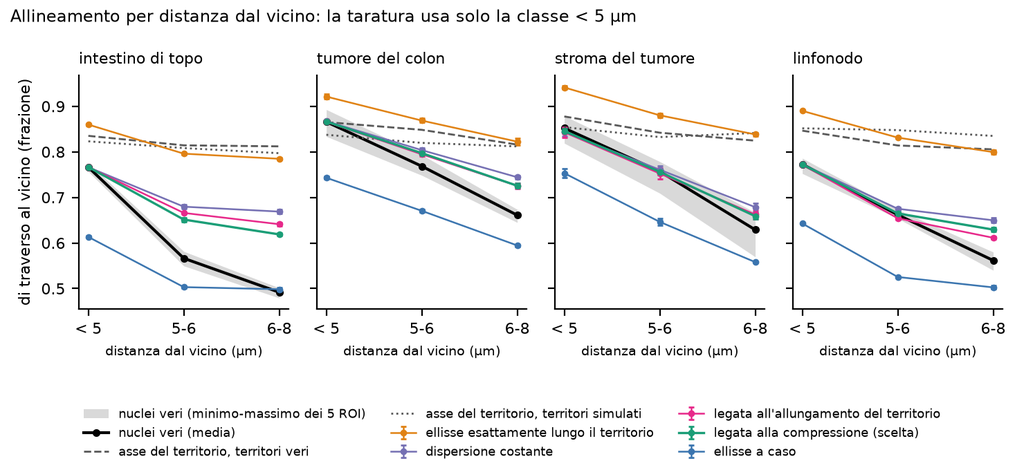

Quota dei nuclei allungati con l’asse lungo di traverso al vicino, per distanza dal vicino (ROI, stima ± 2 errori standard). Banda: minimo-massimo dei 5 ROI veri. Linee tratteggiate e punteggiate: asse del territorio, nei territori veri e nei simulati (PH-1).

Cosa guardare: sotto i 5 µm le tre leggi coincidono con il vero (è la classe della taratura); a 5-8 µm il vero cala verso il caso mentre i nuclei simulati restano più allineati; l’asse del territorio è di traverso al vicino allo stesso modo nei tessuti veri e nei simulati.

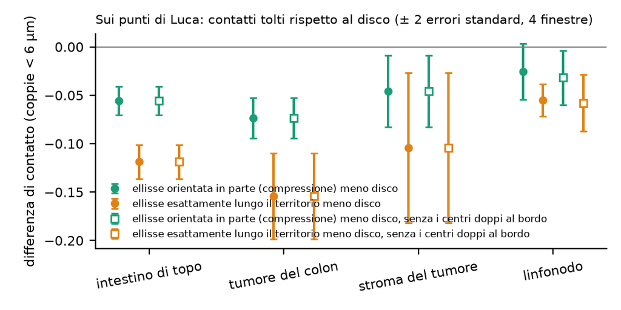

Sui punti di Luca come centri: differenza di contatto rispetto al disco per le coppie giudicate a meno di 6 µm (4 finestre per tessuto, ± 2 errori standard), con e senza i centri del segmentatore entro 1 µm da un punto di Luca.

Cosa guardare: il nucleo orientato in parte toglie circa la metà dei contatti tolti dall’ellisse orientata esattamente; togliere i doppioni al bordo non sposta nulla.

# Dopo il risultato: taratura, cancelli, controprove, post hoc e revisione avversariale

Codice e test al commit `ea26c00`; risultati prima della revisione al commit `176e93c`; correzioni della revisione e post hoc al commit di chiusura (vedi «S1.4f: revisione avversariale …»). Tabelle: `results/S1.4f/S1.4f_lambda.csv`, `S1.4f_ruleO.csv`, `S1.4f_ruleO_cells.csv`, `S1.4f_verdicts.csv`, `S1.4f_ruleN2.csv`, `S1.4f_cp.csv`, `S1.4f_S1.csv`, `S1.4f_desc.csv`, `S1.4f_PH1_territory_nn.csv`, `S1.4f_PH2_verdicts.csv`.

### Taratura e regola O

Taratura lascia-fuori-un-ROI: 90 valori di λ (3 leggi × 30 ROI), nessuno agli estremi della griglia (`S1.4f_lambda.csv`); curve dell’allineamento in t = 1 − exp(−λ) monotone (`S1.4f_cal_curves.csv`). λ della legge scelta (compressione): intestino 0.81-0.86, tumore del colon 0.81-0.99, stroma 0.41-0.49, linfonodo 0.64-0.71, cuore 0.42-0.78, cervello 0.674 (mediana degli altri).

Regola O (`S1.4f_ruleO.csv`): caselle di P-5 dentro R-4 con i semi 1-5: compressione 3/8 (somma degli scarti 0.412), allungamento 3/8 (0.445), costante 1/8 (0.560). **Vince la compressione, per lo spareggio**: EP = V2. Registrato in S1.4f: orientamento parziale con la Cauchy avvolta; la regola O sceglie la compressione; la regola N2 tiene il disco (DEC-028).

### Cancelli

| id | esito | dettaglio |
| --- | --- | --- |
| G-1 | PASS | `test_S1.4f.R` 28/28 (25 pre-registrate più T1b, K2 = `place_cells()` su altri due preset, e T11, compressione con l’area bersaglio prima del tetto, aggiunte dopo la revisione); `tools/S1.4f_test.py` … |
| G-2 | PASS | 6/6 pre-registrati (M2 al secondo tentativo: il primo pattern non si applicava, D-3; M6 rilevato dopo il rafforzamento di T9, D-1); 18/18 con M7-M18 = i 12 mutanti della revisione del codice, prima no… |
| G-3 | PASS | unità = RV di S1.5d 300/300 (banco B) e 150/150 (taratura); K2 ed ET = S1.4e 300/300 ciascuno nel banco B e 240/240 ciascuno nel banco A (WKB); 0 violazioni di contenimento, sovrapposizione, area, val… |
| G-4 | PASS | asse del territorio, allungamento e peso ricalcolati in Python dai poligoni: scarto massimo 8.3e-13 (limite 1e-9); uniformità di F_ρ(2δ) p ≥ 0.075 in 18 combinazioni legge × tessuto; dopo la revisione… |
| G-5 | PASS | due revisori indipendenti (sotto): ricalcolo identico entro 1e-9 di taratura, regola O, P-1…P-5, regola N2, CP-1, CP-2, S-1; nessun errore che cambi un verdetto. |

### Previsioni

Stima ± 2 errori standard; esito. P-1 e P-2: seme (10); P-3, P-4, P-5: ROI (5). K2 ed ET coincidono con S1.4e (scarto ≤ 1.1e-16).

| id | tessuto | intervallo | K2 | EP (compressione) | ET |
| --- | --- | --- | --- | --- | --- |
| P-1 | intestino | 0.366-0.650 | 0.569 ± 0.024 confermata | 0.514 ± 0.025 confermata | 0.472 ± 0.023 confermata |
| P-1 | tumore del colon | 0.217-0.567 | 0.686 ± 0.044 smentita | 0.639 ± 0.040 smentita | 0.594 ± 0.030 indeterminata |
| P-1 | stroma | 0.083-0.283 | 0.360 ± 0.051 smentita | 0.340 ± 0.062 indeterminata | 0.279 ± 0.050 indeterminata |
| P-1 | linfonodo | 0.350-0.750 | 0.833 ± 0.019 smentita | 0.781 ± 0.024 smentita | 0.735 ± 0.019 indeterminata |
| P-1 | cervello | 0.000-0.217 | 0.144 ± 0.016 confermata | 0.129 ± 0.021 confermata | 0.113 ± 0.017 confermata |
| P-1 | cuore | 0.000-0.070 | 0.070 ± 0.025 indeterminata | 0.065 ± 0.017 indeterminata | 0.057 ± 0.020 indeterminata |
| P-2 | intestino | 0.235-0.481 | 0.521 ± 0.023 smentita | 0.463 ± 0.019 indeterminata | 0.418 ± 0.020 confermata |
| P-2 | tumore del colon | 0.083-0.515 | 0.865 ± 0.021 smentita | 0.792 ± 0.022 smentita | 0.743 ± 0.033 smentita |
| P-2 | stroma | 0.188-0.900 | 0.853 ± 0.041 confermata | 0.786 ± 0.038 confermata | 0.690 ± 0.060 confermata |
| P-2 | linfonodo | 0.139-0.451 | 0.549 ± 0.022 smentita | 0.493 ± 0.019 smentita | 0.450 ± 0.019 indeterminata |
| P-3 | intestino / tumore / stroma / linfonodo / cuore | R-2 | smentita 5/5 | 0.767 / 0.866 / 0.845 / 0.773 / 0.796, **confermata 5/5** | smentita 5/5 |
| P-4 | 6 tessuti | R-3 | smentita 6/6 | confermata 6/6 | confermata 6/6 |
| P-5 | 8 caselle | R-4 | smentita 8/8 | **confermata 3, indeterminata 1, smentita 4** | smentita 8/8 |

P-5 per legge (`S1.4f_verdicts.csv`): costante confermata 1, indeterminata 1, smentita 6; allungamento 1, 3, 4; compressione 3, 1, 4. Le caselle smentite di EP: intestino a 5-6 µm (0.651 contro 0.550-0.581) e a 6-8 µm (0.619 contro 0.479-0.501), tumore del colon a 6-8 µm (0.726 contro 0.645-0.674), linfonodo a 6-8 µm (0.629 contro 0.540-0.580); tutte per eccesso.

Rispetto alle attese.

- **P-1.** Esiti di EP come attesi in tutti e sei i tessuti. EP − K2, differenze appaiate per seme: intestino −0.055 ± 0.012, tumore del colon −0.047 ± 0.012, stroma −0.019 ± 0.026, linfonodo −0.052 ± 0.020 (`S1.4f_desc.csv`). L’attesa «fra −0.08 e −0.02» torna in 3 tessuti; nello stroma −0.019 sta a 0.001 dal limite, entro 2 errori standard da esso e anche da zero. Il cuore resta basso in tutti i bracci.
- **P-2.** EP fra ET e K2 in 4/4; esiti come attesi (intestino indeterminata, a 0.08 errori standard dal bordo: estremo 0.4823 contro 0.4815, revisione CR-06).
- **P-3.** Confermata 5/5, come atteso: la taratura su ROI diversi da quello giudicato si trasferisce.
- **P-4.** Confermata 6/6 (prova debole, come scritto).
- **P-5. Smentita: 4 caselle su 8 nel vero o al limite, contro almeno 6 attese.** Tutte le leggi allineano troppo a 5-8 µm; la regola della compressione è la meno lontana.
- **Descrittiva.** Quota dell’effetto di ET conservata da EP: 0.56, 0.52, 0.24, 0.53 (attesa 0.3-0.9: lo stroma sta sotto); posizione dell’allineamento di EP sotto i 5 µm fra caso ed ET: 0.62, 0.69, 0.49, 0.52.

### Regola N2

Punteggio (confermate in P-1 e P-2): K2 3, ET 4, EP 3. ET escluso da (a) e da (c) (P-3 smentita 5/5); EP escluso da (a). **Resta K2** (`S1.4f_ruleN2.csv`), come atteso.

### Controprove e sensibilità

- **CP-1, stessi centri: superata.** EP − K2: intestino −0.056 ± 0.015, tumore del colon −0.074 ± 0.021, stroma −0.046 ± 0.037, linfonodo −0.026 ± 0.029; sotto zero oltre 2 errori standard in 3/4 (attesa ≥ 2). ET − K2: −0.119, −0.154, −0.104, −0.055; EP toglie meno di ET in 4/4 (attesa ≥ 3), circa la metà (0.44-0.48).
- **CP-2, dispersione costante: superata.** V0 smentita in 6 caselle su 8 (attesa ≥ 4).
- **Il cuore**, controllo negativo: P-1 indeterminata in K2, EP, ET (0.070, 0.065, 0.057 contro al più 0.070), come previsto.
- **S-1 (BL-174): nessun effetto oltre il rumore.** I centri del segmentatore entro 1 µm da un punto di Luca sono 6, tutti nel linfonodo (1, 1, 4 in tre finestre); i contrasti di CP-1 cambiano al più di 0.006 (8/8 entro 2 errori standard). Limiti (revisione N-4, CR-08): togliere un centro rinumera le cellule e quindi cambia le estrazioni casuali di tutte le cellule successive, per cui S-1 confronta due realizzazioni; restano 12 centri candidati doppioni fra 1 e 2 µm, non tolti.

### Post hoc (dichiarati dopo il risultato)

- **PH-1, perché P-5 è smentita.** Quota dei territori allungati con l’asse di traverso al vicino (`S1.4f_PH1_territory_nn.csv`): a 6-8 µm, territori veri (Voronoi dei centroidi del segmentatore) 0.81-0.82, territori simulati 0.80-0.84; nuclei veri 0.50-0.66 (intestino 0.50, come il caso). Sotto i 5 µm: territori veri 0.84-0.88, nuclei veri 0.77-0.87. **I territori simulati hanno la geometria dei veri; è il nucleo vero che smette di seguire il territorio quando il vicino non lo stringe**, più in fretta di quanto facciano le tre leggi a un parametro. Una legge più ripida allineerebbe meno a 5-8 µm e toglierebbe meno contatti: la conclusione sui contatti non cambia. Dubbio spiegato; la legge più ripida è rinviata (BL-175).
- **PH-2, la regola O decisa dallo spareggio.** Contatti della legge perdente (allungamento) misurati come EP (`S1.4f_PH2_verdicts.csv`): P-1 0.510 / 0.626 / 0.334 / 0.775 / 0.125 / 0.064 contro 0.514 / 0.639 / 0.340 / 0.781 / 0.129 / 0.065; stessi esiti in tutte le 10 voci, punteggio 3 come EP. Lo spareggio non cambia nessuna conclusione. Dubbio chiuso.

### Correzioni e note

- D-1 (cancello G-2, prima della lettura dei verdetti): T9 non rilevava M6 (la coppia a 7 µm non cambia classe spostando il confine a 7 µm); coppia spostata a 6.5 µm.
- D-2 (revisione N-1 e CR-03): la taratura legge i valori veri per ROI arrotondati a 4 decimali (colonna `roi_values` di `S1.4f_refs.csv`); con i valori pieni λ cambia al più di 1.1e-3 e la quota attesa al più di 5e-5, contro errori standard di 0.002-0.02. Nessun verdetto può cambiare; non si rifà la catena.
- D-3 (strumenti, nessun effetto sui risultati): pattern di M2 sbagliato al primo tentativo; nelle copie dei mutanti lo script di misura cercava `S1.4e_measure.py` accanto a sé; lo stadio delle coppie si è fermato una volta per un errore di serializzazione dei processi (modulo non registrato) ed è ripartito dagli stadi fatti.
- D-4 (revisione CR-04): G-4 descritto come controllo di coerenza; aggiunto il controllo non tautologico del coseno.
- D-5 (revisione CR-05, CR-09): batteria rafforzata (T1b, T11, T13-T21; M7-M18); analisi e taratura spezzate in funzioni piccole per poterle provare, uscite identiche (nessuna differenza nei file committati).
- D-6 (revisione CR-10): la catena ricalcolava taratura e regola O a ogni rilancio (risultati deterministici e identici); ora le salta se le uscite esistono. L’ordine pre-registrato (regola O prima di raster e coppie di EP) è verificato dal revisore dai tempi dei file e dai nuclei rasterizzati.
- D-0 (protocollo, principio 4): durante l’esplorazione F1 lo script `tools/S1.4f_explore.py` è stato scritto per pochi minuti nel workspace locale dell’agente, poi caricato sul server e cancellato in locale; tutto il resto del codice è stato scritto solo sul server. Nessun effetto sui risultati; violazione dichiarata.
- Nota (revisione CR-08): i conteggi dei candidati doppioni nella nota del revisore del codice dicono 6 fra 2 e 3 µm; la sua tabella dà 5. Il numero non entra in nessuna conclusione.
- Nota (revisione CR-02): la compressione usa l’area bersaglio del nucleo prima dei tetti, come scritto nella pre-registrazione; ora coperta da T11 e M17.

### Revisione avversariale

- Revisore numerico: ricalcolo da zero con codice proprio di 90 λ, allineamento della legge scelta su 120 unità del banco B (intestino e linfonodo tutte, tumore e stroma 10 ciascuno), regola O, P-1 e P-2 di EP dai raster e dalle coppie, 111 verdetti, regola N2, CP-1, S-1 e contatto di coppia del banco A contro una sua rasterizzazione (3 finestre × 3 bracci × 10 semi, 0 discordanze su 9 450 righe). Nessuna discrepanza sopra 1e-9. Note: D-2, regola O per spareggio (PH-2), attese mancate di EP (P-5, stroma), S-1 non locale.
- Revisore del codice: diff del pacchetto (flusso casuale e asse del territorio invariati senza colonne nuove; quantile corretto; nessun NaN agli estremi), banco (EP del banco A rigenerato bit per bit su 6 finestre, un seme), taratura, regole O e N2, uscite (nessun doppione, chiavi complete); profilo rimisurato su 90 unità; 12 mutanti propri, 0 rilevati dalla batteria di allora, ora 12/12 (D-5). Nessun errore che cambi numeri o verdetti; 11 rilievi, tutti chiusi sopra.

Controprova CP-1 (stessi centri), sensibilità S-1 (senza i doppioni al bordo) e cuore

| id | archetype | contrast | est | se | lo2 | hi2 | below_zero | n_pairs | verdict |
| --- | --- | --- | --- | --- | --- | --- | --- | --- | --- |
| CP-1 | A1 | EP-K2 | -0.056 | 0.007 | -0.071 | -0.041 | True | 89 |  |
| CP-1 | A1 | ET-K2 | -0.119 | 0.009 | -0.136 | -0.101 | True | 89 |  |
| CP-1 | A2 | EP-K2 | -0.074 | 0.010 | -0.095 | -0.053 | True | 30 |  |
| CP-1 | A2 | ET-K2 | -0.154 | 0.022 | -0.198 | -0.110 | True | 30 |  |
| CP-1 | A3 | EP-K2 | -0.046 | 0.018 | -0.083 | -0.009 | True | 17 |  |
| CP-1 | A3 | ET-K2 | -0.104 | 0.039 | -0.182 | -0.027 | True | 17 |  |
| CP-1 | A4 | EP-K2 | -0.026 | 0.015 | -0.055 | 0.003 | False | 121 |  |
| CP-1 | A4 | ET-K2 | -0.055 | 0.008 | -0.072 | -0.038 | True | 121 |  |
| S-1 | A1 | EP-K2 | -0.056 | 0.007 | -0.071 | -0.041 | True | 89 |  |
| S-1 | A1 | ET-K2 | -0.119 | 0.009 | -0.136 | -0.101 | True | 89 |  |
| S-1 | A2 | EP-K2 | -0.074 | 0.010 | -0.095 | -0.053 | True | 30 |  |
| S-1 | A2 | ET-K2 | -0.154 | 0.022 | -0.198 | -0.110 | True | 30 |  |
| S-1 | A3 | EP-K2 | -0.046 | 0.018 | -0.083 | -0.009 | True | 17 |  |
| S-1 | A3 | ET-K2 | -0.104 | 0.039 | -0.182 | -0.027 | True | 17 |  |
| S-1 | A4 | EP-K2 | -0.032 | 0.014 | -0.060 | -0.004 | True | 121 |  |
| S-1 | A4 | ET-K2 | -0.058 | 0.015 | -0.087 | -0.029 | True | 121 |  |
| cuore | A6 | K2 | 0.070 | 0.012 | NA | NA |  | NA | indeterminata |
| cuore | A6 | ET | 0.057 | 0.010 | NA | NA |  | NA | indeterminata |
| cuore | A6 | EP | 0.065 | 0.008 | NA | NA |  | NA | indeterminata |

S-1: variazione dei contrasti di CP-1 togliendo i doppioni (entro 2 errori standard)

| archetype | contrast | delta | se_A | within_2se |
| --- | --- | --- | --- | --- |
| A1 | EP-K2 | 0.0000 | 0.0075 | True |
| A1 | ET-K2 | 0.0000 | 0.0088 | True |
| A2 | EP-K2 | 0.0000 | 0.0105 | True |
| A2 | ET-K2 | 0.0000 | 0.0220 | True |
| A3 | EP-K2 | 0.0000 | 0.0185 | True |
| A3 | ET-K2 | 0.0000 | 0.0387 | True |
| A4 | EP-K2 | -0.0061 | 0.0145 | True |
| A4 | ET-K2 | -0.0028 | 0.0084 | True |

PH-2: contatti della legge perdente della regola O (V1) contro EP

| id | archetype | arm | est | se | lo | hi | verdict |
| --- | --- | --- | --- | --- | --- | --- | --- |
| P-1 | A1 | V1 | 0.510 | 0.012 | 0.366 | 0.650 | confermata |
| P-2 | A1 | V1 | 0.463 | 0.011 | 0.235 | 0.481 | indeterminata |
| P-1 | A2 | V1 | 0.626 | 0.017 | 0.217 | 0.567 | smentita |
| P-2 | A2 | V1 | 0.780 | 0.014 | 0.083 | 0.515 | smentita |
| P-1 | A3 | V1 | 0.334 | 0.028 | 0.083 | 0.283 | indeterminata |
| P-2 | A3 | V1 | 0.784 | 0.022 | 0.188 | 0.900 | confermata |
| P-1 | A4 | V1 | 0.775 | 0.012 | 0.350 | 0.750 | smentita |
| P-2 | A4 | V1 | 0.489 | 0.008 | 0.139 | 0.451 | smentita |
| P-1 | A5 | V1 | 0.125 | 0.010 | 0.000 | 0.217 | confermata |
| P-1 | A6 | V1 | 0.064 | 0.008 | 0.000 | 0.070 | indeterminata |
| P-1 | A1 | EP | 0.514 | 0.012 | 0.366 | 0.650 | confermata |
| P-2 | A1 | EP | 0.463 | 0.010 | 0.235 | 0.481 | indeterminata |
| P-1 | A2 | EP | 0.639 | 0.020 | 0.217 | 0.567 | smentita |
| P-2 | A2 | EP | 0.792 | 0.011 | 0.083 | 0.515 | smentita |
| P-1 | A3 | EP | 0.340 | 0.031 | 0.083 | 0.283 | indeterminata |
| P-2 | A3 | EP | 0.786 | 0.019 | 0.188 | 0.900 | confermata |
| P-1 | A4 | EP | 0.781 | 0.012 | 0.350 | 0.750 | smentita |
| P-2 | A4 | EP | 0.493 | 0.010 | 0.139 | 0.451 | smentita |
| P-1 | A5 | EP | 0.129 | 0.011 | 0.000 | 0.217 | confermata |
| P-1 | A6 | EP | 0.065 | 0.008 | 0.000 | 0.070 | indeterminata |

PH-1: quota di traverso al vicino per classe di distanza; asse del territorio (veri e simulati) e asse del nucleo vero

| source | what | archetype | frac.nn<5 | frac.nn5-6 | frac.nn6-8 |
| --- | --- | --- | --- | --- | --- |
| real | nucleus | A1 | 0.769 | 0.571 | 0.497 |
| real | territory | A1 | 0.835 | 0.814 | 0.812 |
| sim | territory | A1 | 0.823 | 0.808 | 0.797 |
| real | nucleus | A2 | 0.865 | 0.769 | 0.664 |
| real | territory | A2 | 0.865 | 0.848 | 0.816 |
| sim | territory | A2 | 0.837 | 0.820 | 0.812 |
| real | nucleus | A3 | 0.853 | 0.756 | 0.631 |
| real | territory | A3 | 0.878 | 0.842 | 0.825 |
| sim | territory | A3 | 0.854 | 0.832 | 0.841 |
| real | nucleus | A4 | 0.777 | 0.664 | 0.565 |
| real | territory | A4 | 0.847 | 0.814 | 0.805 |
| sim | territory | A4 | 0.852 | 0.848 | 0.835 |
| real | nucleus | A5 | 0.441 | 0.848 | 0.692 |
| real | territory | A5 | 0.787 | 0.547 | 0.856 |
| sim | territory | A5 | 0.864 | 0.950 | 0.817 |
| real | nucleus | A6 | 0.793 | 0.438 | 0.439 |
| real | territory | A6 | 0.792 | 0.822 | 0.851 |
| sim | territory | A6 | 0.850 | 0.856 | 0.886 |

# Cosa è girato

- Taratura: 150 unità (30 ROI × semi 1-5) × 3 leggi × 12 valori di λ = 5 400 ridisegni, 24.5 minuti; banco B: 300 unità (seme = 20261021 + 1000 · i + s, come S1.5d, S1.5e, S1.4e) × 5 bracci, 12.2 minuti; banco A: 24 finestre × 10 semi × 3 bracci × 2 versioni (con e senza doppioni), 8.3 minuti; lesexp-server, 20 worker a un thread. Catena completa circa un’ora (una ripresa dopo un errore di serializzazione nello stadio delle coppie). Test, mutanti e regressioni circa mezz’ora per passata, tre passate.
- md5 dei 4 147 file letti (dati veri, annotazioni, modelli di taglia di S1.4 e R3b, nuclei, raster e coppie di S1.4e) identici prima e dopo.
- Comandi esatti nella sezione «Riproduzione» del file dello step.

G-3: identità e invarianti

| check | value | expected | pass |
| --- | --- | --- | --- |
| B_units | 300 | 300 | TRUE |
| B_RV_equals_S1.5d_RV_md5 | 300 | 300 | TRUE |
| cal_RV_equals_S1.5d_RV_md5 | 150 | 150 | TRUE |
| B_K2_equals_S1.4e | 300 | 300 | TRUE |
| B_ET_equals_S1.4e | 300 | 300 | TRUE |
| A_K2_equals_S1.4e | 240 | 240 | TRUE |
| A_ET_equals_S1.4e | 240 | 240 | TRUE |
| cal_rows | 5400 | 5400 | TRUE |
| A_rows | 1440 | 1440 | TRUE |
| invariant_violations_cal | 0 | 0 | TRUE |
| invariant_violations_B | 0 | 0 | TRUE |
| invariant_violations_A | 0 | 0 | TRUE |

G-4: seconda implementazione della legge e dell’estrazione

| check | value | limit | pass_ |
| --- | --- | --- | --- |
| territory_axis_max_diff_rad | 0.0000 | 0.00 | True |
| territory_aspect_max_diff | 0.0000 | 0.00 | True |
| weight_max_diff | 0.0000 | 0.00 | True |
| ks_uniform_min_p | 0.0753 | 0.01 | True |
| mean_cos2delta_minus_rho_max_abs_z (dopo la revisione) | 1.2084 | 4.00 | True |

G-4 per legge e tessuto

| law | archetype | n | ks_p | mean_cos_minus_rho | z_cos |
| --- | --- | --- | --- | --- | --- |
| V0 | A1 | 45364 | 0.1961 | -0.0005 | -0.1764 |
| V0 | A2 | 37808 | 0.7638 | 0.0034 | 1.2084 |
| V0 | A3 | 15429 | 0.4814 | 0.0016 | 0.3039 |
| V0 | A4 | 139991 | 0.7251 | 0.0002 | 0.1013 |
| V0 | A5 | 4722 | 0.4013 | -0.0019 | -0.2101 |
| V0 | A6 | 4575 | 0.0753 | -0.0001 | -0.0054 |
| V1 | A1 | 45364 | 0.1961 | 0.0003 | 0.1022 |
| V1 | A2 | 37808 | 0.7638 | 0.0015 | 0.5229 |
| V1 | A3 | 15429 | 0.4814 | 0.0033 | 0.6167 |
| V1 | A4 | 139991 | 0.7251 | 0.0009 | 0.5390 |
| V1 | A5 | 4722 | 0.4013 | -0.0020 | -0.2350 |
| V1 | A6 | 4575 | 0.0753 | 0.0007 | 0.0666 |
| V2 | A1 | 45274 | 0.1835 | 0.0005 | 0.1749 |
| V2 | A2 | 37749 | 0.7439 | 0.0028 | 1.0198 |
| V2 | A3 | 15427 | 0.4880 | 0.0014 | 0.2589 |
| V2 | A4 | 139940 | 0.7374 | 0.0002 | 0.1496 |
| V2 | A5 | 4702 | 0.4118 | -0.0043 | -0.4813 |
| V2 | A6 | 4571 | 0.0809 | 0.0043 | 0.4268 |

# Appendice

## Dubbi ricevuti

| voce | cosa | perché conta | cosa serve per chiuderla |
| --- | --- | --- | --- |
| BL-171 (da S1.4e, P-3, CP-1, regola N) | l’ellisse orientata lungo l’asse del territorio toglie circa un contatto su dieci nei tessuti densi ma allinea troppo: quota di nuclei di traverso al vicino 0.86-0.94 contro 0.77-0.87 nei veri; il ver… | è l’unico disegno del nucleo che finora ha tolto contatti senza peggiorare nessun tessuto; Luca ha scelto di provare l’orientamento parziale (DEC-027) | orientamento lungo il territorio con dispersione tarata sull’allineamento vero, con pieghe lascia-fuori-un-ROI, giudicato su P-1, P-2, P-3 come in S1.4e; nel tumore del colon e nello stroma il riferim… |
| BL-174 (da S1.4e, revisione) | nel banco A alcuni punti di Luca hanno un centro del segmentatore entro 2 µm appena fuori dalla finestra (probabilmente lo stesso nucleo contato due volte al bordo); nessuna coppia giudicata coinvolta | potrebbe gonfiare i contatti dei nuclei al bordo della finestra nella controprova sugli stessi centri | togliere i centri del segmentatore entro 1 µm da un punto di Luca e ripetere CP-1 come sensibilità |

Collegate, toccate dai risultati e aggiornate alla chiusura: BL-063 (allineamento fra nucleo e territorio), BL-123 (forma del nucleo), BL-142 (contatti del linfonodo).

## Esplorazione prima della pre-registrazione

Solo dati veri (F1) e unità già simulate in S1.4e (F2); nessuna simulazione nuova[^explore].

**F1. L’asse del nucleo vero segue quello del suo territorio, ma poco, e solo quando il vicino è vicino.** Nuclei del segmentatore di forma (Cellpose nell’intestino, nel tumore, nello stroma e nel cervello; StarDist nel linfonodo e nel cuore), territori di Voronoi dei loro centroidi; cellule con nucleo allungato (≥ 1.2), territorio allungato (≥ 1.1), a ≥ 20 µm dal bordo del ROI, territorio ≤ 4 volte la mediana. Quota con l’asse del nucleo entro 45° da quello del territorio: 0.50 (cuore) - 0.68 (tumore del colon) su tutte le cellule; con il vicino a meno di 5 µm 0.71 (intestino), 0.79 (tumore), 0.77 (stroma), 0.74 (linfonodo); a 6-8 µm 0.49, 0.64, 0.60, 0.53. Forma della distribuzione dell’angolo (`S1.4f_F1_summary.csv`): una miscela «quota allineata esattamente, il resto a caso» è molto peggiore (log-verosimiglianza più bassa di 177-1 396 su tutte le cellule dei tessuti densi) di una distribuzione unimodale; fra le due unimodali provate, von Mises e Cauchy avvolta, la differenza è piccola (sotto i 5 µm von Mises meglio di 9-74 unità su 1 924-25 706 cellule, cioè al più 0.006 per cellula; su tutte le cellule del linfonodo Cauchy meglio di 70). Limite: l’asse del territorio vero è rumoroso (nuclei persi o in più del segmentatore), quindi F1 sottostima l’allineamento vero rispetto al territorio e non si usa per tarare.

**F2. Il territorio simulato dà un allineamento che non cala con la distanza come quello vero.** Sulle 300 unità di S1.4e (banco B), quota dei nuclei allungati di traverso al vicino, per classe di distanza dal vicino, contro i nuclei veri (`S1.4f_F2_units.csv`, `S1.4f_refs.csv`). Posizione del vero fra l’ellisse a caso (0) e l’ellisse orientata esattamente (1):

| tessuto | < 5 µm | 5-6 µm | 6-8 µm |
| --- | --- | --- | --- |
| intestino | 0.62 | 0.22 | -0.02 |
| tumore del colon | 0.69 | 0.49 | 0.29 |
| stroma | 0.53 | 0.47 | 0.25 |
| linfonodo | 0.53 | 0.45 | 0.20 |

Con l’ellisse orientata esattamente la quota resta alta anche a 6-8 µm (0.79-0.84 contro 0.49-0.66 nei veri): l’asse del territorio è di traverso al vicino a ogni distanza, mentre il nucleo vero lo segue solo quando il vicino lo stringe. Una dispersione costante tarata sotto i 5 µm allineerebbe quindi troppo a 5-8 µm. Per questo lo step prova, oltre alla dispersione costante scritta in BL-171, due leggi in cui la dispersione si stringe quando la cellula è più compressa, e lascia scegliere ai dati (regola O).

## Pre-registrazione (testo del file dello step)

Commit dei cancelli e della pre-registrazione: `ebb2b34`. Ok di Luca sulle previsioni, le regole O e N2 e le controprove: 2026-10-28, «vai» (in chat, dopo la pagina in linguaggio semplice). Commit: vedi «S1.4f: ok di Luca».

### Il nucleo orientato in parte (nel pacchetto)

Ellisse con l’allungamento vero del tessuto (come ER ed ET di S1.4e: 1.667 / 1.598 / 1.705 / 1.250 / 1.207 / 1.705, da B-115…B-120), angolo θ = asse maggiore del territorio + δ. Con lo stesso numero casuale u che oggi dà l’orientamento a caso: 2δ = 2 atan( (1 − ρ)/(1 + ρ) · tan(π (u − 1/2)) ), cioè 2δ con distribuzione di Cauchy avvolta centrata in 0 e lunghezza risultante media ρ (ρ = 0: a caso; ρ = 1: esattamente lungo il territorio). Scelta della Cauchy avvolta (decisione tecnica, F1): si adatta quanto la von Mises e si inverte in forma chiusa con un solo numero casuale, quindi i bracci restano appaiati seme per seme. Concentrazione per cellula ρ_i = 1 − exp(−λ w_i), con λ ≥ 0 per tessuto e tre leggi:

| legge | w_i | idea |
| --- | --- | --- |
| V0 costante | 1 | dispersione uguale per tutte le cellule (BL-171 alla lettera) |
| V1 allungamento | allungamento del territorio − 1 (radice del rapporto dei momenti principali) | un territorio rotondo non dà direzione |
| V2 compressione | raggio equivalente dell’area bersaglio del nucleo / distanza del centro dal bordo del territorio | nel Voronoi la distanza dal bordo è metà della distanza dal vicino più vicino: w_i > 1 vuol dire che il disco non ci starebbe |

Nel catalogo dei tipi: colonne opzionali `nucleus_orient_conc` (λ, predefinito Inf = esattamente lungo il territorio, come oggi) e `nucleus_orient_law` (`"constant"` predefinito, `"elongation"`, `"compression"`), valide solo con `nucleus_orient = "territory"`. Senza le colonne il comportamento è bit per bit quello di oggi.

### Bracci e banchi

| braccio | nucleo |
| --- | --- |
| K2 | disco ritagliato nel territorio e riportato all’area giusta (preset di oggi) |
| ET | ellisse esattamente lungo il territorio (S1.4e) |
| EP | ellisse orientata in parte: legge scelta dalla regola O, λ della piega lascia-fuori-un-ROI |

**Banco B**: le 300 unità di S1.5d/S1.4e (6 tessuti × 5 ROI × 10 semi, stessi semi, BASE 20261021), nuclei ridisegnati sugli stessi centri e territori come in S1.4e. **Banco A**: le 24 finestre di R2b con i punti di Luca come centri, 10 semi, come S1.4e. K2 ed ET devono coincidere bit per bit con S1.4e (G-3); le loro misure si riprendono da S1.4e.

**Taratura (lascia-fuori-un-ROI).** Griglia λ ∈ {0, 0.1, 0.2, 0.35, 0.5, 0.75, 1, 1.5, 2, 3, 5, 10} più ET (λ = ∞), per ogni legge, sui semi 1-5 del banco B. Per il ROI di prova r: curva simulata = media sui 4 altri ROI (ciascuno media dei semi 1-5) della quota P-3 sotto i 5 µm; bersaglio = media dei valori veri R-2 degli stessi 4 ROI; λ_r = soluzione per interpolazione lineare della curva nella variabile t = 1 − exp(−λ) (t = 1 per ET); se la curva non è monotona, il primo incrocio; se il bersaglio sta fuori dalla curva, l’estremo più vicino (dichiarato). Il cervello (P-3 esclusa: 103 nuclei veri in 2 ROI) usa la mediana dei 25 λ_r degli altri cinque tessuti per la legge scelta. Il cuore si tara come gli altri.

### Regola O (sceglie la legge, decisa dai dati prima di guardare i contatti)

Per ogni legge, con i λ_r della taratura e i semi 1-5: quota P-3 nelle classi 5-6 µm e 6-8 µm (non usate nella taratura) nei 4 tessuti densi, valore del ROI = media dei semi, stima = media dei 5 ROI. Punteggio = numero delle 8 caselle con la stima dentro R-4 = [minimo, massimo] dei 5 ROI veri. Vince il punteggio più alto; a pari punteggio, la somma più piccola di |stima − media vera| sulle 8 caselle. La legge vincente diventa EP. La regola si applica prima di calcolare raster, contatti e coppie di EP; il risultato si registra come decisione tecnica.

### Cancelli (al massimo 5)

| id | controllo | tolleranza | comando |
| --- | --- | --- | --- |
| G-1 | **batteria di test** `R/testing/test_S1.4f.R` e `tools/S1.4f_test.py`: (T1) senza le colonne nuove e con λ = Inf i nuclei sono bit per bit quelli di oggi (K2 ridisegnato = `place_cells()` su 3 preset;… | nuovi tutti PASS; regressioni con i soli FAIL noti | `bash R/testing/run_S1.4f.sh test` |
| G-2 | **mutanti** (copie del codice): M1 δ non dimezzato (2δ usato come δ); M2 legge ignorata (w = 1 sempre); M3 taratura con il ROI di prova incluso; M4 (1 − ρ)/(1 + ρ) invertito; M5 raggio di BL-174 a 2 µ… | 6/6 rilevati | `bash R/testing/run_S1.4f.sh mutants` |
| G-3 | **identità e invarianti**: unità = RV di S1.5d (md5 del livello, 300/300); K2 ed ET ridisegnati = nuclei di S1.4e (WKB, 300/300 ciascuno; banco A 240/240 ciascuno); in tutti i bracci, nella griglia di… | 300/300, 300/300, 240/240, 0 violazioni, md5 invariati | `Rscript --vanilla tools/S1.4f_bench.R check` |
| G-4 | **seconda implementazione della legge e dell’estrazione**: su 30 unità di EP (una per ROI, seme 1) si ricalcolano in Python, dai poligoni dei territori, l’asse del territorio, w_i e ρ_i, poi δ_i = ang… | asse del territorio e w_i entro 1e-9 da quelli del pacchetto; KS di uniformità p > 0.01 in ogni tessuto | `.venv/bin/python tools/S1.4f_measure.py g4` |
| G-5 | **ricalcolo indipendente** della revisione avversariale: due revisori ricalcolano dal codice e dai dati la taratura (λ_r), la regola O, P-1…P-5, CP-1, CP-2, la sensibilità S-1 e la regola N2 | identico o ≤ 1e-9 | revisione |

### Previsioni

Unità indipendente per l’incertezza: P-1 e P-2 **seme** (finestre fisse, 10 semi; stima = media dei semi ± 2 errori standard, errore standard = deviazione standard fra semi / √10), come S1.4e; P-3, P-4, P-5 **ROI** (valore del ROI = media dei 10 semi; 5 ROI; errore standard = deviazione standard fra ROI / √5). Nessun bootstrap sul simulato. Intervalli: B-127…B-132; R-1, R-2, R-3 di S1.4e; R-4 nuovo, calcolato prima di ogni simulazione nuova (`S1.4f_refs.csv`[^refs]).

| id | quantità | tessuto | atteso | intervallo di rilevanza | fonte | 2 errori standard tipici |
| --- | --- | --- | --- | --- | --- | --- |
| P-1 | frazione di nuclei focali con almeno un vicino a contatto, finestre di R2c (banco B) | intestino / tumore del colon / stroma / linfonodo / cervello / cuore | K2 ed ET = S1.4e (per costruzione). EP fra i due: nei 4 tessuti densi EP − K2 fra −0.08 e −0.02 (toglie meno di ET, più di nulla); esiti di EP: intestino confermata; tumore del colon smentita o indete… | 0.366-0.650 / 0.217-0.567 / 0.083-0.283 / 0.350-0.750 / 0.000-0.217 / 0.000-0.070 | B-127…B-132 | 0.02-0.05 |
| P-2 | frazione di coppie a contatto con i centri a meno di 6 µm (banco B) | intestino / tumore del colon / stroma / linfonodo | EP fra ET e K2 in tutti e quattro; esiti di EP: intestino confermata o indeterminata; tumore del colon smentita; stroma confermata; linfonodo smentita o indeterminata | 0.235-0.481 / 0.083-0.515 / 0.188-0.900 / 0.139-0.451 | R-1 (S1.4e) | 0.02-0.06 |
| P-3 | allineamento sotto i 5 µm: quota dei nuclei allungati (≥ 1.2) con il vicino a meno di 5 µm e asse maggiore di traverso al vicino (> 45°) (banco B) | intestino / tumore del colon / stroma / linfonodo / cuore | EP confermata o indeterminata in almeno 4 su 5 (tarata, ma su ROI diversi da quello giudicato); ET smentita 5/5 (S1.4e) | 0.757-0.776 / 0.834-0.893 / 0.819-0.879 / 0.752-0.786 / 0.741-0.857 | R-2 (S1.4e) | 0.002-0.02 |
| P-4 | eccentricità mediana del nucleo (banco B) | 6 tessuti | EP confermata o indeterminata 6/6 (prova debole: l’allungamento viene dalle stesse eccentricità) | come S1.4e | R-3 (S1.4e) | 0.005-0.02 |
| P-5 | allineamento a 5-6 µm e a 6-8 µm (stessa quota di P-3, altre classi di distanza) (banco B) | intestino / tumore del colon / stroma / linfonodo (8 caselle) | EP confermata o indeterminata in almeno 6 su 8 | 5-6 µm: 0.550-0.581 / 0.748-0.793 / 0.709-0.779 / 0.654-0.673; 6-8 µm: 0.479-0.501 / 0.645-0.674 / 0.569-0.667 / 0.540-0.580 | R-4 (nuovo) | 0.003-0.02 |

Avvisi. P-5 non è una prova indipendente: le stesse classi scelgono la legge (regola O, semi 1-5); è una scelta fra tre leggi a un parametro tarato altrove, quindi l’ottimismo è piccolo ma c’è. P-3 è tarata su ROI diversi da quello giudicato: misura quanto l’allineamento si trasferisce fra ROI dello stesso tessuto, non se il modello lo spiega. Gli intervalli di R-2 e R-4 sono stretti (larghezza 0.02-0.10) rispetto a 2 errori standard di 0.002-0.02: un esito indeterminato vorrà dire che la stima è vicina a un estremo, non che manca precisione. Area del nucleo, tetto φ e rapporto nucleo/territorio non cambiano fra i bracci per costruzione (G-3).

Descrittiva con attesa (non è una previsione giudicata): quota dell’effetto di ET conservata da EP, (P-1 di EP − P-1 di K2) / (P-1 di ET − P-1 di K2), nei 4 tessuti densi: attesa fra 0.3 e 0.9, vicina alla posizione dell’allineamento sotto i 5 µm (0.5-0.7).

Cosa direbbe una smentita.

- **EP toglie i contatti quanto ET pur con l’allineamento giusto**: l’effetto viene dalle cellule più compresse, che anche l’orientamento parziale allinea; EP diventerebbe la proposta per i preset.
- **EP non toglie contatti (EP − K2 entro 2 errori standard da 0)**: serve l’allineamento esatto per togliere contatti; l’orientamento non è la spiegazione biologica dell’eccesso.
- **P-5 smentita per tutte e tre le leggi**: la dispersione legata al territorio non riproduce come l’allineamento cala con la distanza; il nucleo vero risponde al vicino, non alla forma del suo territorio.

### Regola N2 (proposta per i preset, decisa dai dati)

Come la regola N di S1.4e, con una condizione in più sull’allineamento. Punteggio di un braccio = numero di previsioni **confermate** fra P-1 (6 tessuti) e P-2 (4 tessuti): 10 voci. EP o ET diventano la proposta per i preset solo se (a) superano K2 di almeno 2 voci, (b) nessun tessuto confermato da K2 in P-1 diventa smentito, (c) P-3 non è smentita in più di 2 dei 5 tessuti. ET non può vincere per (c) (P-3 smentita 5/5 in S1.4e): resta come riferimento. A pari punteggio fra bracci ammessi vince quello con più P-3 confermate; se resta il pari, resta K2. Il cambio dei preset si fa al consolidamento dello Step 1, come per le quote (DEC-025), salvo che Luca lo chieda prima.

### Controprove

- **CP-1, stessi centri (banco A).** Coppie giudicate da Luca («non giudicabile» escluse), centri a meno di 6 µm: differenza di contatto EP − K2 sulle stesse coppie, media dei 10 semi per finestra, stima = media delle 4 finestre ± 2 errori standard fra finestre. Attesa: EP − K2 < 0 oltre 2 errori standard in almeno 2 dei 4 tessuti densi, e EP − K2 non più negativa di ET − K2 (stime puntuali) in almeno 3 su 4. Se EP non abbassasse i contatti sugli stessi centri in nessun tessuto, l’effetto del banco B verrebbe dall’interazione con la semina, non dal disegno del nucleo.
- **CP-2, la dispersione costante.** La legge V0 (BL-171 alla lettera) con i suoi λ_r: attesa smentita in almeno 4 delle 8 caselle di P-5 (troppo allineata a 5-8 µm, F2). Se V0 fosse confermata o indeterminata in almeno 6 su 8, la lettura di F2 sarebbe sbagliata e la legge non servirebbe.
- **Il cuore**, controllo negativo previsto per il Voronoi isotropo: contatti bassi in tutti i bracci (P-1 confermata o indeterminata).

### Sensibilità S-1 (BL-174)

Banco A ripetuto per K2, ET ed EP togliendo i centri del segmentatore entro 1 µm da un punto di Luca. Attesa: i contrasti di CP-1 (ET − K2 ed EP − K2) cambiano meno di 2 errori standard in tutti e 4 i tessuti densi, perché nessuna coppia giudicata è coinvolta. Se cambiassero di più, CP-1 di S1.4e e di questo step andrebbe riletta con il banco corretto.

### Calcolo e tempi (stima dell’agente)

Taratura: 150 unità (semi 1-5) × 3 leggi × 12 valori di λ = 5 400 ridisegni, circa 5 ore di processore (S1.4e: 0.29 ore per 300 ridisegni), più 150 semine (1 ora) e la misura dell’allineamento (F2: 600 unità in 5 minuti con 20 processi, quindi circa 45 minuti). Poi EP sulle 300 unità, K2 ed ET per l’identità, raster e coppie di EP, banco A con EP e la sensibilità S-1. Stima complessiva circa 30 ore di processore, cioè 2.5-3 ore con 20 worker a un thread sul server del laboratorio (libero il 2026-10-28, Tctl 37 °C), più circa un’ora per test e mutanti. Uscite stabili in `/mnt/micron/geo_spatialtrans/S1.4f`, un file per unità, rilanciabili.

## Descrittive e riferimenti

Descrittive senza verdetto

| desc | archetype | est | se | n | arm |
| --- | --- | --- | --- | --- | --- |
| P-1 quota dell’effetto di ET conservata da EP | A1 | 0.5620 | NA | NA |  |
| P-3 posizione di EP fra ER (0) ed ET (1) | A1 | 0.6220 | NA | NA |  |
| P-1 differenza EP - K2 appaiata per seme | A1 | -0.0547 | 0.0060 | 10 |  |
| P-1 quota dell’effetto di ET conservata da EP | A2 | 0.5155 | NA | NA |  |
| P-3 posizione di EP fra ER (0) ed ET (1) | A2 | 0.6918 | NA | NA |  |
| P-1 differenza EP - K2 appaiata per seme | A2 | -0.0472 | 0.0059 | 10 |  |
| P-1 quota dell’effetto di ET conservata da EP | A3 | 0.2368 | NA | NA |  |
| P-3 posizione di EP fra ER (0) ed ET (1) | A3 | 0.4903 | NA | NA |  |
| P-1 differenza EP - K2 appaiata per seme | A3 | -0.0190 | 0.0128 | 10 |  |
| P-1 quota dell’effetto di ET conservata da EP | A4 | 0.5283 | NA | NA |  |
| P-3 posizione di EP fra ER (0) ed ET (1) | A4 | 0.5251 | NA | NA |  |
| P-1 differenza EP - K2 appaiata per seme | A4 | -0.0517 | 0.0102 | 10 |  |
| P-2 classe lt6 | A1 | 0.4630 | 0.0096 | 10 |  |
| P-2 classe 6to10 | A1 | 0.0061 | 0.0015 | 10 |  |
| P-2 classe lt6 | A2 | 0.7920 | 0.0112 | 10 |  |
| P-2 classe 6to10 | A2 | 0.2115 | 0.0082 | 10 |  |
| P-2 classe lt6 | A3 | 0.7857 | 0.0192 | 10 |  |
| P-2 classe 6to10 | A3 | 0.2261 | 0.0088 | 10 |  |
| P-2 classe lt6 | A4 | 0.4933 | 0.0096 | 10 |  |
| P-2 classe 6to10 | A4 | 0.0036 | 0.0011 | 10 |  |
| banco A < 6 um | A1 | 0.4506 | NA | 89 | K2 |
| banco A < 6 um | A1 | 0.3292 | NA | 89 | ET |
| banco A < 6 um | A1 | 0.3921 | NA | 89 | EP |
| banco A < 6 um | A2 | 0.8633 | NA | 30 | K2 |
| banco A < 6 um | A2 | 0.7167 | NA | 30 | ET |
| banco A < 6 um | A2 | 0.7900 | NA | 30 | EP |
| banco A < 6 um | A3 | 0.8647 | NA | 17 | K2 |
| banco A < 6 um | A3 | 0.7353 | NA | 17 | ET |
| banco A < 6 um | A3 | 0.8059 | NA | 17 | EP |
| banco A < 6 um | A4 | 0.4182 | NA | 121 | K2 |
| banco A < 6 um | A4 | 0.3653 | NA | 121 | ET |
| banco A < 6 um | A4 | 0.4008 | NA | 121 | EP |

Taratura lascia-fuori-un-ROI: lambda per legge e ROI di prova

| law | archetype | roi_id | t | lambda | clamped | target |
| --- | --- | --- | --- | --- | --- | --- |
| V0 | A1 | r1 | 0.5733 | 0.8517 | False | 0.7666 |
| V0 | A1 | r2 | 0.5657 | 0.8339 | False | 0.7640 |
| V0 | A1 | r3 | 0.5837 | 0.8762 | False | 0.7688 |
| V0 | A1 | r4 | 0.5805 | 0.8686 | False | 0.7666 |
| V0 | A1 | r5 | 0.5723 | 0.8493 | False | 0.7657 |
| V0 | A2 | r1 | 0.6806 | 1.1412 | False | 0.8740 |
| V0 | A2 | r2 | 0.6408 | 1.0238 | False | 0.8665 |
| V0 | A2 | r3 | 0.6692 | 1.1062 | False | 0.8704 |
| V0 | A2 | r4 | 0.6122 | 0.9472 | False | 0.8598 |
| V0 | A2 | r5 | 0.6091 | 0.9393 | False | 0.8593 |
| V0 | A3 | r1 | 0.3962 | 0.5045 | False | 0.8490 |
| V0 | A3 | r2 | 0.4514 | 0.6004 | False | 0.8602 |
| V0 | A3 | r3 | 0.4325 | 0.5665 | False | 0.8566 |
| V0 | A3 | r4 | 0.3808 | 0.4793 | False | 0.8488 |
| V0 | A3 | r5 | 0.3850 | 0.4861 | False | 0.8453 |
| V0 | A4 | f1 | 0.4792 | 0.6524 | False | 0.7734 |
| V0 | A4 | f2 | 0.4674 | 0.6299 | False | 0.7709 |
| V0 | A4 | p1 | 0.4599 | 0.6161 | False | 0.7697 |
| V0 | A4 | p2 | 0.4731 | 0.6407 | False | 0.7726 |
| V0 | A4 | p3 | 0.4953 | 0.6839 | False | 0.7781 |
| V0 | A6 | r1 | 0.5568 | 0.8138 | False | 0.8067 |
| V0 | A6 | r2 | 0.3643 | 0.4531 | False | 0.7799 |
| V0 | A6 | r3 | 0.5022 | 0.6975 | False | 0.8090 |
| V0 | A6 | r4 | 0.3894 | 0.4933 | False | 0.7915 |
| V0 | A6 | r5 | 0.3983 | 0.5079 | False | 0.7896 |
| V0 | A5 | r1 | 0.4953 | 0.6839 | False | NA |
| V0 | A5 | r2 | 0.4953 | 0.6839 | False | NA |
| V0 | A5 | r3 | 0.4953 | 0.6839 | False | NA |
| V0 | A5 | r4 | 0.4953 | 0.6839 | False | NA |
| V0 | A5 | r5 | 0.4953 | 0.6839 | False | NA |

[output cut: 60 more lines]

Intervalli R-2 e R-4 calcolati sui dati veri prima del banco

| ref | archetype | cls | n | n_roi | est | lo | hi |
| --- | --- | --- | --- | --- | --- | --- | --- |
| R-2 | A1 | nn<5 | 20557 | 5 | 0.766 | 0.757 | 0.776 |
| R-4 | A1 | nn5-6 | 6524 | 5 | 0.566 | 0.550 | 0.581 |
| R-4 | A1 | nn6-8 | 5292 | 5 | 0.492 | 0.479 | 0.501 |
| R-2 | A2 | nn<5 | 6050 | 5 | 0.866 | 0.834 | 0.893 |
| R-4 | A2 | nn5-6 | 6358 | 5 | 0.768 | 0.748 | 0.793 |
| R-4 | A2 | nn6-8 | 9695 | 5 | 0.661 | 0.645 | 0.674 |
| R-2 | A3 | nn<5 | 2217 | 5 | 0.852 | 0.819 | 0.879 |
| R-4 | A3 | nn5-6 | 2849 | 5 | 0.757 | 0.709 | 0.779 |
| R-4 | A3 | nn6-8 | 5373 | 5 | 0.629 | 0.569 | 0.667 |
| R-2 | A4 | nn<5 | 29771 | 5 | 0.773 | 0.752 | 0.786 |
| R-4 | A4 | nn5-6 | 24124 | 5 | 0.662 | 0.654 | 0.673 |
| R-4 | A4 | nn6-8 | 8836 | 5 | 0.562 | 0.540 | 0.580 |
| R-2 | A5 | nn<5 | 103 | 2 | 0.426 | 0.308 | 0.544 |
| R-4 | A5 | nn5-6 | 32 | 3 | 0.794 | 0.667 | 1.000 |
| R-4 | A5 | nn6-8 | 117 | 5 | 0.699 | 0.333 | 1.000 |
| R-2 | A6 | nn<5 | 104 | 5 | 0.795 | 0.741 | 0.857 |
| R-4 | A6 | nn5-6 | 79 | 5 | 0.419 | 0.333 | 0.500 |
| R-4 | A6 | nn6-8 | 251 | 5 | 0.439 | 0.351 | 0.508 |

## Da dove vengono i numeri del riassunto

| frase del riassunto | fonte (tabella o file, riga) | valore letto |
| --- | --- | --- |
| intestino 0.57 → 0.51 | S1.4f_verdicts.csv, P-1 intestino, K2 ed EP | 0.57 0.51 |
| tumore del colon 0.69 → 0.64 (vero al più 0.57) | S1.4f_verdicts.csv, P-1 tumore del colon | 0.69 0.64 0.57 |
| stroma 0.36 → 0.34 (al più 0.28) | S1.4f_verdicts.csv, P-1 stroma | 0.36 0.34 0.28 |
| linfonodo 0.83 → 0.78 (al più 0.75) | S1.4f_verdicts.csv, P-1 linfonodo | 0.83 0.78 0.75 |
| circa metà dei contatti tolti dall’orientamento esatto; nello stroma un quarto | S1.4f_desc.csv, quota dell’effetto di ET conservata da EP (intestino, tumore, linfonodo; stroma) | 0.52-0.56 0.24 |
| tumore del colon e linfonodo fuori dal vero, stroma al limite | S1.4f_verdicts.csv, P-1 EP | smentita smentita indeterminata |
| 3 misure di contatto su 10, come il disco; ne servivano almeno 2 in più | S1.4f_ruleN2.csv | 3 3 K2 |
| allineamento dei nuclei vicini giusto in 5 tessuti su 5 | S1.4f_verdicts.csv, P-3 EP | 5 |
| con tutte e tre le regole troppo allineati a 5-8 µm | S1.4f_verdicts.csv, P-5 caselle smentite per V0, V1, V2 | 6 4 4 |
| intestino a 6-8 µm: veri metà di traverso, come a caso; simulati 62 su 100 | S1.4f_refs.csv R-4 intestino nn6-8 (stima); S1.4f_verdicts.csv P-5 EP intestino nn6-8 | 0.49 62 |
| asse del territorio di traverso circa 8 volte su 10 nei veri e nei simulati (6-8 µm) | S1.4f_PH1_territory_nn.csv, territori, tessuti densi, nn6-8 | 81-82 80-84 |
| sui tuoi punti toglie da 3 a 7 coppie su 100 sotto i 6 µm | S1.4f_cp.csv, CP-1 EP-K2 | 3-7 |
| circa metà dell’orientamento esatto | S1.4f_cp.csv, CP-1 (EP-K2)/(ET-K2) | 0.44-0.48 |
| togliere i nuclei contati due volte non cambia il risultato | S1.4f_S1.csv, contrasti entro 2 errori standard | 8/8 |
| tu 17 su 100, Federica 44 (stesse coppie vicine del tumore) | results/S1.4e/S1.4e_PH1_raters.csv, tumore < 6 µm | 17 44 |
| taratura 24,5 minuti, 300 simulazioni 12,2, 24 finestre 8,3 | S1.4f_chain_run1.log (calB, genB), S1.4f_chain_run2.log (genA) | 24.5 12.2 8.3 |
| catena circa un’ora con 20 processori | registro dei job del server: 2703 s (fino all’arresto dello stadio delle coppie) + 794 s (ripresa) | 58 min |
| test, mutanti e regressioni circa mezz’ora per passata; tre passate | registro dei job del server: 2278 s, 2170 s, 2046 s | 34-38 min, 3 |